# Lab 04 — Sampling from Time Series

EAES 480 — Modern Statistics in Earth & Environmental Science

February 16, 2026

# Overview

## What is AmeriFlux?

**AmeriFlux** is a network of **eddy covariance** flux-tower sites that measure exchanges of **carbon (CO₂), water, and energy** between ecosystems and the atmosphere, with standardized data products shared for research and education.

In this lab, you will use a simplified AmeriFlux-style dataset from the **US-AMS site at Argonne National Laboratory (near Chicago)**. The measurements are at **30-minute resolution** over **2023**, and show strong **seasonality** and **day–night cycles**.

**Key idea for this lab:** treat the full 2023 time series as the **population**, then practice sampling strategies to estimate population parameters.

References for context: - AmeriFlux overview: https://ameriflux.lbl.gov/about/about-ameriflux/ - US-AMS site page: https://ameriflux.lbl.gov/sites/siteinfo/US-AMS

# Learning goals

By the end of this lab, you should be able to:

- Define a **population** and a **sample** for an EAES time-series dataset
- Compute population **parameters** (mean, SD) and compare to sample **estimates**
- Visualize distributions and identify **latent grouping variables** (month, day/night)
- Implement **simple random sampling** and **stratified sampling**
- Use `set.seed()` to make sampling reproducible

# Data

## Load and inspect

```r
df <- read_csv("data/us-ams-simple.csv") %>%
  clean_names() %>% filter(year_local == 2023)

glimpse(df)
```

```
## Rows: 16,973
## Columns: 10
## $ year_local <dbl> 2023, 2023, 2023, 2023, 2023, 2023, 2023, 2023, 2023, 2023,…
## $ doy        <dbl> 1.0000, 1.0208, 1.0416, 1.0624, 1.0833, 1.1041, 1.1249, 1.1…
## $ daytime    <dbl> 0, 0, 0, 0, 0, 0, 0, 0, -9999, -9999, 0, 0, 0, 0, 0, 0, 1, …
## $ fc         <dbl> 1.4444700, 1.0018700, 1.7665700, 0.4639850, 0.8243290, 0.64…
## $ le         <dbl> -2.975490, -1.814240, -5.101540, -4.854642, -2.419090, -10.…
## $ ta         <dbl> 7.433350, 7.783740, 8.273390, 8.702240, 8.896600, 8.567610,…
## $ reco       <dbl> 1.291612, 1.312279, 1.341193, 1.366625, 1.378268, 1.359013,…
## $ gpp        <dbl> -0.1528577, 0.3104090, -0.4253767, 0.9026402, 0.5539394, 0.…
## $ swc        <dbl> 36.13111, 36.11948, 36.11560, 36.11172, 36.11172, 36.10008,…
## $ ts         <dbl> 2.50, 2.50, 2.50, 2.50, 2.50, 2.50, 2.50, 2.50, 2.50, 2.50,…
```

**CHECK:** You should see columns like `year_local`, `doy`, `daytime`, and flux/biomet variables (e.g., `gpp`, `fc`, `le`, `ta`).

## Create a date and month column from DOY

This dataset uses **Year + Day-of-Year (DOY)**. Month must be derived from a calendar date.

```r
df <- df %>%
  filter(year_local == 2023, doy >= 1, doy <= 366)
df <- df %>%
  mutate(
    # TODO: create a Date column from year_local and doy
    # HINT: Jan 1 is DOY = 1, so use (doy - 1) with origin = "YYYY-01-01"
    date = as.Date(doy - 1, origin = paste0(year_local, "-01-01")),

    # TODO: create a month column (numeric 1–12 or labeled months)
    month = month(date, label = TRUE, abbr = TRUE),

    # TODO: make a day/night label using daytime (0/1)
    day_night = if_else(daytime == 1, "Day", "Night")
  )

count(df, month)
```

| month | n |
| --- | --- |
| Jan | 1488 |
| Feb | 1344 |
| Mar | 1486 |
| Apr | 1440 |
| May | 1488 |
| Jun | 1440 |
| Jul | 1488 |
| Aug | 1452 |
| Sep | 1440 |
| Oct | 1488 |

[output cut: 2 more lines]

```r
count(df, day_night)
```

| day_night | n |
| --- | --- |
| Day | 8287 |
| Night | 8650 |

# Choose a response variable

You will analyze **one response variable** throughout the lab. This could be a CO₂ flux metric or a meteorological variable.

Examples you can choose from (depending on what you see in the dataset): - CO₂ / carbon: `gpp`, `reco`, `fc` - Energy: `le` - Meteorology: `ta`, `ts`, `swc`

```r
# TODO: choose ONE response variable (a column name as a string)
response_var <- "le"   # replace "gpp" with your choice, e.g. "fc" or "le" or "ta"

# CHECK: print a quick summary
df %>% summarise(
  n = n(),
  n_missing = sum(is.na(.data[[response_var]])),
  mean = mean(.data[[response_var]], na.rm = TRUE),
  sd = sd(.data[[response_var]], na.rm = TRUE)
)
```

| n | n_missing | mean | sd |
| --- | --- | --- | --- |
| 16937 | 0 | 61.37161 | 80.57007 |

**Prompt (2–3 sentences):** Why did you choose this response variable? What do you expect its seasonality/day–night pattern to be?

> I choose le (energy) as the response variable because it directly reflects the energy exchange between the surface and the atmosphere. I expect that le will be strong in summer and weak in winter,and it should be higher during the day and lower or close to zero at night.

# Section 1 — Data dictionary (conceptual)

Students will populate the data dictionary using: https://ameriflux.lbl.gov/data/aboutdata/data-variables/

Fill in at least **5 variables** from this dataset:

| Variable | Units | Description | Expected sign/seasonality? |
| --- | --- | --- | --- |
| le | W m-2 | Latent heat turbulent flux (no storage correction) | Summer high, winter low. Typically higher during daytime and near zero at night. Strong seasonality |
| DO | µmol L-1 | Dissolved oxygen in water | Higher in colder seasons |
| PCH4 | nmolCH4 mol-1 | Dissolved methane (CH4) in water | Higher in warm seasons |
| PCO2 | µmolCO2 mol-1 | Dissolved carbon dioxide (CO2) in water | Higher in warm seasons |
| DBH | cm | Diameter of tree measured at breast height (1.3m) with continuous dendrometers | May have seasonal growth pulses (spring/summer) |

# Section 2 — Visualizing the population

Remember: for this lab, the **population** is the entire 2023 half-hourly time series.

## 2.1 Time series view

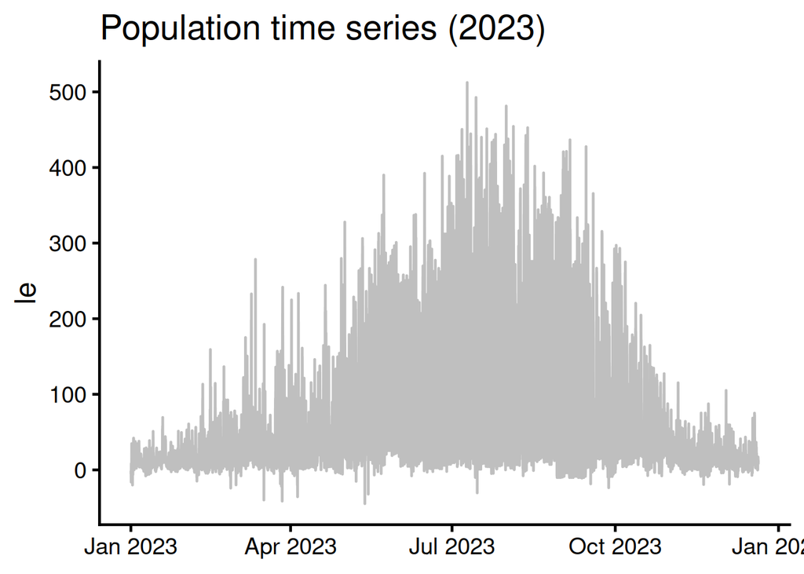

```r
# GOAL: Visualize seasonality over the year.
# TODO: pick a y aesthetic using response_var.

df %>%
  ggplot(aes(x = date, y =.data[[response_var]])) +
  geom_line(alpha = 0.25) +
  theme_classic(base_size = 18) +
  labs(
    x = NULL,
    y = response_var,
    title = "Population time series (2023)"
  )
```

**Prompt (2–3 sentences):** What major patterns do you see? (Seasonal cycle? Daily cycle? Outliers?)

> The LE time series shows a clear seasonal pattern across 2023. Values are much higher in the summer and much lower (often near zero) in the winter. There is also noticeable short-term variation throughout the year, which likely reflects day–night changes and weather events.

## 2.2 Population distribution (histogram + density)

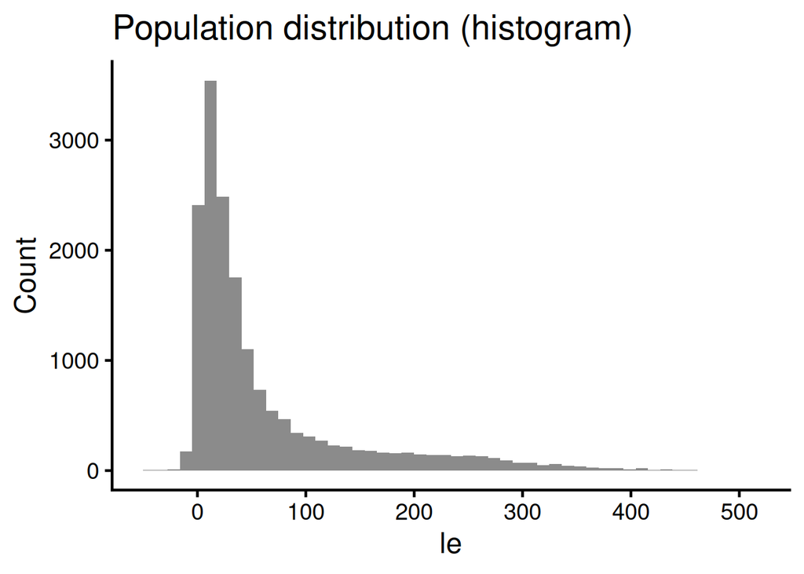

```r
# GOAL: See the overall distribution of the population.
# TODO: choose an appropriate number of bins (start with ~50).

ggplot(df, aes(x = .data[[response_var]])) +
  geom_histogram(bins = 50, alpha = 0.7) +
  theme_classic(base_size = 18) +
  labs(x = response_var, y = "Count", title = "Population distribution (histogram)")
```

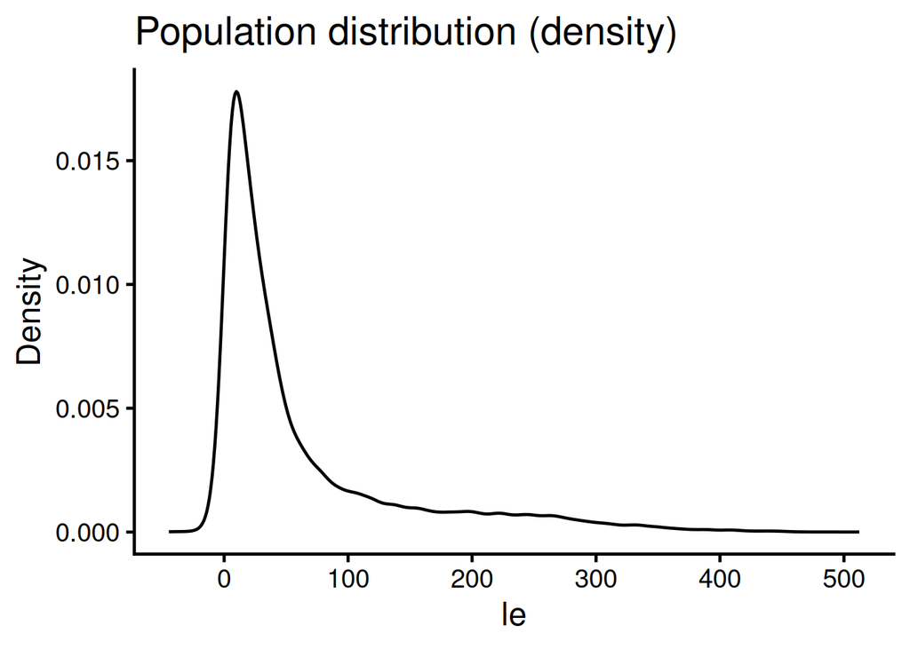

```r
ggplot(df, aes(x = .data[[response_var]])) +
  geom_density(alpha = 0.7) +
  theme_classic(base_size = 18) +
  labs(x = response_var, y = "Density", title = "Population distribution (density)")
```

**Prompt:** Describe shape (skew, modality), center, and spread.

> LE is very right-skewed, with lots of low values and a long tail of high values. The high LE values probably happen mostly during summer daytime, while winter and nighttime values stay close to zero.

## 2.3 Do latent groups explain variability? (month, day/night)

### By month

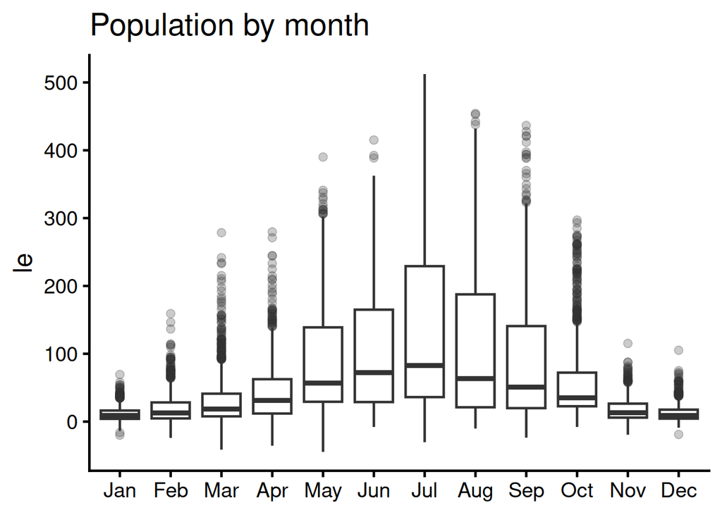

```r
# TODO: make month appear in a sensible order (it already is an ordered factor if label=TRUE)
df %>%
  ggplot(aes(x = month, y = .data[[response_var]])) +
  geom_boxplot(outlier.alpha = 0.25) +
  theme_classic(base_size = 18) +
  labs(x = NULL, y = response_var, title = "Population by month")
```

### By day/night

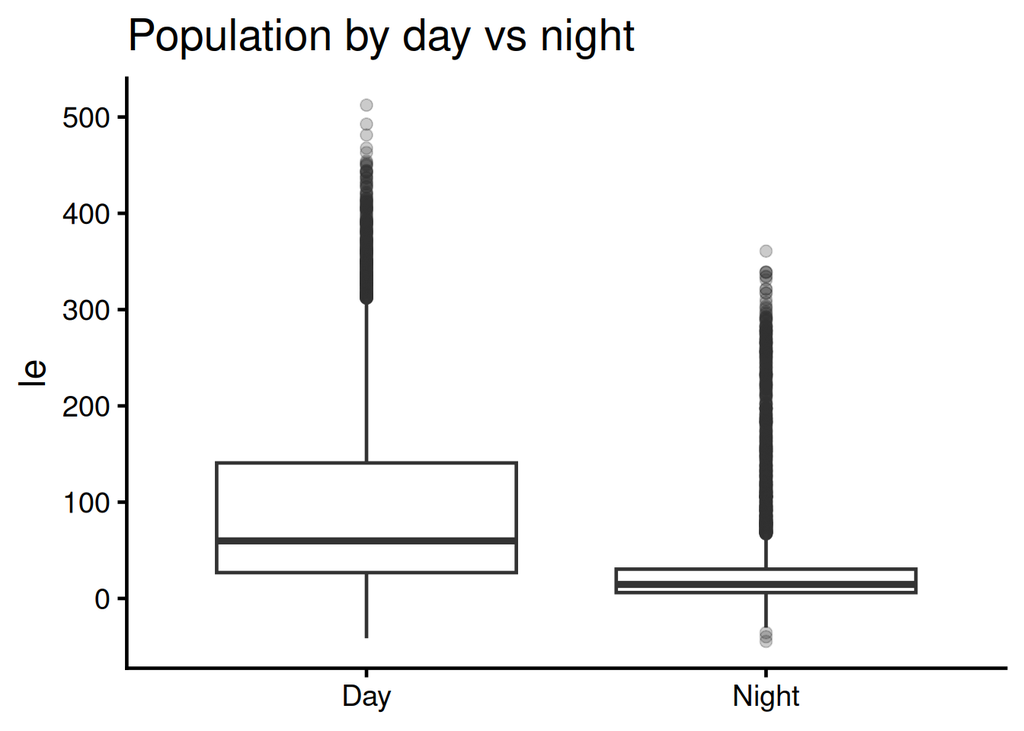

```r
df %>%
  ggplot(aes(x = day_night, y = .data[[response_var]])) +
  geom_boxplot(outlier.alpha = 0.25) +
  theme_classic(base_size = 18) +
  labs(x = NULL, y = response_var, title = "Population by day vs night")
```

**Prompt (3–4 sentences):** Which grouping variable (month or day/night) seems to explain more variability in your response? Why?

## > I think month explains more variability in LE because the values are much higher in summer and much lower in winter. Day vs night is also important since LE is usually higher during the day and close to zero at night. But the seasonal change across months looks bigger overall.

# Section 3 — Population parameters (truth)

Compute the population mean and SD for your chosen response variable.

```r
pop_mean <- mean(df[[response_var]], na.rm = TRUE)
pop_sd   <- sd(df[[response_var]], na.rm = TRUE)

tibble(
  response_var = response_var,
  population_mean = pop_mean,
  population_sd = pop_sd
)
```

| response_var | population_mean | population_sd |
| --- | --- | --- |
| le | 61.37161 | 80.57007 |

# Section 4 — Simple random sampling (SRS)

## 4.1 One random sample

```r
set.seed(480)

# TODO: choose a sample size (e.g., 200, 500, 1000)
n_samp <- 200

samp <- df %>%
  slice_sample(n = n_samp)

samp_mean <- mean(samp[[response_var]], na.rm = TRUE)
samp_sd   <- sd(samp[[response_var]], na.rm = TRUE)

tibble(
  n_samp = n_samp,
  sample_mean = samp_mean,
  sample_sd = samp_sd,
  pop_mean = pop_mean,
  pop_sd = pop_sd
)
```

| n_samp | sample_mean | sample_sd | pop_mean | pop_sd |
| --- | --- | --- | --- | --- |
| 200 | 63.01461 | 81.63108 | 61.37161 | 80.57007 |

**Prompt (2–3 sentences):** How close is your one-sample estimate to the population mean/SD? Is the difference surprising?

> The one-sample estimate was pretty close to the population values. The sample mean (63.01) is only slightly higher than the population mean (61.37), and the SD is also very similar. Any small differences are expected since this is just one random sample of 200 points.

## 4.2 Sampling variability: many samples → many means

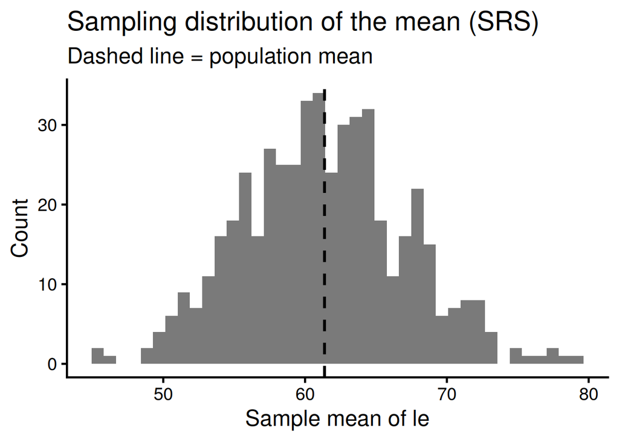

```r
set.seed(480)

reps <- 500   # TODO: choose number of replicates (e.g., 500 or 1000)

means <- replicate(
  reps,
  df %>%
    slice_sample(n = n_samp) %>%
    summarise(m = mean(.data[[response_var]], na.rm = TRUE)) %>%
    pull(m)
)

ggplot(tibble(mean_est = means), aes(mean_est)) +
  geom_histogram(bins = 40, alpha = 0.8) +
  geom_vline(xintercept = pop_mean, linetype = "dashed", linewidth = 1.1) +
  theme_classic(base_size = 18) +
  labs(
    x = paste0("Sample mean of ", response_var),
    y = "Count",
    title = "Sampling distribution of the mean (SRS)",
    subtitle = "Dashed line = population mean"
  )
```

**Prompt (2–3 sentences):** Is the sampling distribution centered on the population mean? What happens if you increase `n_samp`?

> Yes, the sampling distribution is centered close to the population mean (dashed line). This suggests that the sample mean is a good estimator of the population mean. If I increase n_samp, the sampling distribution should become narrower, meaning the sample means would vary less from sample to sample.

# Section 5 — Stratified sampling

Here you’ll test whether stratification helps when the population has structure.

## 5.1 Stratify by month

```r
set.seed(480)

# GOAL: sample within each month to ensure seasonal representation.
# TODO: choose n_per_month so total sample size is reasonable (e.g., 12 * 20 = 240)
n_per_month <- 20

samp_strat <- df %>%
  group_by(month) %>%
  slice_sample(n = n_per_month) %>%
  ungroup()

strat_mean <- mean(samp_strat[[response_var]], na.rm = TRUE)
strat_sd   <- sd(samp_strat[[response_var]], na.rm = TRUE)

tibble(
  n_per_month = n_per_month,
  total_n = nrow(samp_strat),
  strat_mean = strat_mean,
  strat_sd = strat_sd,
  pop_mean = pop_mean,
  pop_sd = pop_sd
)
```

| n_per_month | total_n | strat_mean | strat_sd | pop_mean | pop_sd |
| --- | --- | --- | --- | --- | --- |
| 20 | 240 | 65.32893 | 85.39993 | 61.37161 | 80.57007 |

## 5.2 Compare strategies (SRS vs stratified)

```r
tibble(
  strategy = c("Population", "SRS", "Stratified by month"),
  mean = c(pop_mean, samp_mean, strat_mean),
  sd   = c(pop_sd,   samp_sd,   strat_sd)
)
```

| strategy | mean | sd |
| --- | --- | --- |
| Population | 61.37161 | 80.57007 |
| SRS | 63.01461 | 81.63108 |
| Stratified by month | 65.32893 | 85.39993 |

**Prompt (3–4 sentences):** Which strategy better approximated the population mean and SD for your response variable? Why might stratification help (or not) here?

> In this run, SRS was closer to the population mean and SD. The stratified sample mean was higher, probably because it ensured equal representation of summer months when LE is higher. Stratification sampling can help avoid missing parts of the seasonal cycle, but it cannot guarantee a better estimate every time.

# Section 6 — Conceptual reflection

Answer in **4–6 sentences**:

- Why does seasonality matter for sampling?
- What happens if sampling ignores latent grouping variables?
- In EAES field studies, when is stratification essential?
- What is one trade-off of stratified sampling?

> Seasonality matters for sampling because variables like LE change a lot across the year, and summer values are much higher than winter values. If sampling ignores latent grouping variables (like month or day/night), a random sample could accidentally include too many winter or nighttime points, which would bias the estimate of the population mean. In EAES field studies, stratification is essential when the population has strong structure, such as seasonal cycles, elevation zones, land cover types, or different hydrologic conditions. Stratified sampling helps ensure all important conditions are represented. One trade-off is that stratified sampling can be more complicated to design and may require more planning and effort than simple random sampling.

# Part II (Placeholder — to be added)

In the next lab section, we will extend this to **sampling methods in EAES** (e.g., systematic sampling, cluster sampling, sampling frames, and bias) and connect sampling to **hypothesis testing**.

> *Instructor will add this section later. Do not delete this header.*